# Tarea 1 Mineria de Datos

David Romero, Luisa De La Horita,David Moreno

2024-02-19

# 1 Punto 1.1

```r
# Read Inflow Data
weather <- read_excel("WeatherData_1.xlsx", skip = 1, col_names = c("Date", "Rainfall depth (mm)", "Air temperature (°C)", "Air humidity (%)", "Windspeed (km/h)"))

# Read inflow data
inflow <- read_excel("InflowData_1.xlsx", skip = 1, col_names = c("Date", "DMA A", "DMA B", "DMA C", "DMA D", "DMA E", "DMA F", "DMA G", "DMA H", "DMA I", "DMA J"))

# Convert Date column to POSIXct format
weather$Date <- as.POSIXct(weather$Date, format = "%d/%m/%Y %H:%M")
inflow$Date <- as.POSIXct(inflow$Date, format = "%d/%m/%Y %H:%M")

# Merge inflow and weather data frames by "Date" column, retaining all rows from inflow
df_data <- merge(inflow, weather, by = "Date", all.x = TRUE)

# Remove duplicate rows based on the Date column, keeping only the first occurrence
df_data <- df_data[!duplicated(df_data$Date, fromLast = TRUE), ]
```

Primero, procedemos a leer los dos conjuntos de datos y renombrar las columnas con nombres descriptivos. Para facilitar la unión de los conjuntos, utilizaremos “Date” como nombre común para la columna que representa la fecha.

Luego, convertiremos la columna “Date” al formato POSIXct para asegurarnos de que esté en el formato correcto, que es día/mes/año/hora/minuto.

Posteriormente, creamos la variable df_data y unimos las dos bases de datos mediante un left join de la base de datos “Inflow” con la base “weather”.

### 1.0.1 Procesamiento de los datos

```r
str(df_data)
```

```
## 'data.frame':    13678 obs. of  15 variables:
##  $ Date                : POSIXct, format: "2021-01-01 00:00:00" "2021-01-01 01:00:00" ...
##  $ DMA A               : chr  "#N/A" "#N/A" "#N/A" "#N/A" ...
##  $ DMA B               : chr  "#N/A" "#N/A" "#N/A" "#N/A" ...
##  $ DMA C               : chr  "3.7" "3.5625" "3.2725" "2.84" ...
##  $ DMA D               : chr  "#N/A" "#N/A" "#N/A" "#N/A" ...
##  $ DMA E               : chr  "#N/A" "#N/A" "#N/A" "#N/A" ...
##  $ DMA F               : chr  "#N/A" "#N/A" "#N/A" "#N/A" ...
##  $ DMA G               : chr  "#N/A" "#N/A" "#N/A" "#N/A" ...
##  $ DMA H               : chr  "#N/A" "#N/A" "#N/A" "#N/A" ...
##  $ DMA I               : chr  "#N/A" "#N/A" "#N/A" "#N/A" ...
##  $ DMA J               : chr  "#N/A" "#N/A" "#N/A" "#N/A" ...
##  $ Rainfall depth (mm) : num  0 0 0 0 0 0.1 0 0 0.5 0 ...
##  $ Air temperature (°C): num  7.2 7.3 7.6 8.2 7.7 7.5 7.6 7.6 7.2 8 ...
##  $ Air humidity (%)    : num  79 79 78 75 77 81 82 84 91 86 ...
##  $ Windspeed (km/h)    : num  9 6 4 4 7 8 8 9 9 9 ...
```

Aqui vemos que los tipos de datos de las las columnas son númericos y de tipo chr que es string, acá vemos un problema y es que esta tomando el string “#N/A” no como vacio sino como string, las demás variables de DMA deberian ser númericas para esto vamos a hacer una tranformación a los datos

```r
df_data <- df_data %>%
  mutate(
    # First operation: Handle character columns
    across(where(is.character), ~ {
      # Replace "#N/A" with NA, then extract numbers and convert to numeric
      as.numeric(gsub("[^0-9.]+", "", ifelse(. == "#N/A", NA, .)))
    }),
    # Second operation: Convert DMA columns to integer
    across(c(`DMA A`, `DMA B`, `DMA C`, `DMA D`, `DMA E`, `DMA F`, `DMA G`, `DMA H`, `DMA I`, `DMA J`), as.integer)
  )
str(df_data)
```

```
## 'data.frame':    13678 obs. of  15 variables:
##  $ Date                : POSIXct, format: "2021-01-01 00:00:00" "2021-01-01 01:00:00" ...
##  $ DMA A               : int  NA NA NA NA NA NA NA NA NA NA ...
##  $ DMA B               : int  NA NA NA NA NA NA NA NA NA NA ...
##  $ DMA C               : int  3 3 3 2 2 2 2 3 3 4 ...
##  $ DMA D               : int  NA NA NA NA NA NA NA NA NA NA ...
##  $ DMA E               : int  NA NA NA NA NA NA NA NA NA NA ...
##  $ DMA F               : int  NA NA NA NA NA NA NA NA NA NA ...
##  $ DMA G               : int  NA NA NA NA NA NA NA NA NA NA ...
##  $ DMA H               : int  NA NA NA NA NA NA NA NA NA NA ...
##  $ DMA I               : int  NA NA NA NA NA NA NA NA NA NA ...
##  $ DMA J               : int  NA NA NA NA NA NA NA NA NA NA ...
##  $ Rainfall depth (mm) : num  0 0 0 0 0 0.1 0 0 0.5 0 ...
##  $ Air temperature (°C): num  7.2 7.3 7.6 8.2 7.7 7.5 7.6 7.6 7.2 8 ...
##  $ Air humidity (%)    : num  79 79 78 75 77 81 82 84 91 86 ...
##  $ Windspeed (km/h)    : num  9 6 4 4 7 8 8 9 9 9 ...
```

Aqui hacemos un pipeline indicando que remplace todos los strings de la forma “#NA” con NA de variable descriptiva en r, luego extraiga los numeros y los combierta a numerico, y luego convertimos toda las columnas en enteros.

### 1.0.2 Tecnica de imputacion

Para este ejericio vamos a ver la cantidad de Na que tenemos en cada columns para ver que método utilizamos

```r
# Calculate NA proportions for each column
na_proportions <- colMeans(is.na(df_data))

# Create a data frame with column names and NA proportions
na_summary <- data.frame(
  Column = names(na_proportions),
  NA_Proportion = na_proportions
)

# Arrange the summary data frame by NA proportions in descending order
na_summary <- na_summary %>%
  arrange(desc(NA_Proportion))

# Print the summary
print(na_summary)
```

```
##                                    Column NA_Proportion
## DMA F                               DMA F   0.137373885
## DMA I                               DMA I   0.110030706
## DMA G                               DMA G   0.107837403
## DMA H                               DMA H   0.081298435
## DMA D                               DMA D   0.066237754
## DMA J                               DMA J   0.064190671
## DMA A                               DMA A   0.055929229
## Air humidity (%)         Air humidity (%)   0.054540137
## DMA E                               DMA E   0.053004825
## DMA B                               DMA B   0.042915631
## DMA C                               DMA C   0.006726130
## Windspeed (km/h)         Windspeed (km/h)   0.001169762
## Date                                 Date   0.000000000
## Rainfall depth (mm)   Rainfall depth (mm)   0.000000000
## Air temperature (°C) Air temperature (°C)   0.000000000
```

```r
#Primer analisis eliminar NA
df_data_1<-na.omit(df_data)
```

### 1.0.3 Histogramas de las columnas

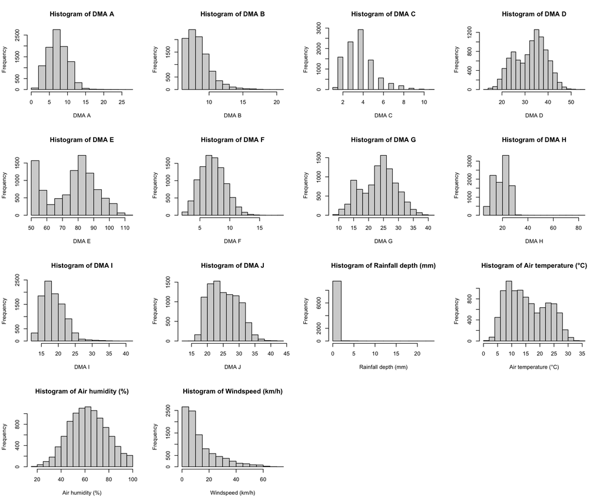

```r
# Identify numeric columns. This is a placeholder; replace it with your actual logic to identify numeric columns
numeric_cols <- sapply(df_data_1, is.numeric)

# Set up the plotting window to display multiple plots based on the number of numeric columns
par(mfrow=c(ceiling(sqrt(sum(numeric_cols))), ceiling(sqrt(sum(numeric_cols)))))

# Loop through each numeric column to create a histogram
for(col in names(df_data_1)[numeric_cols]) {
  hist(df_data_1[[col]], main = paste("Histogram of", col),
       xlab = col, ylab = "Frequency")
}

# Reset plotting window to default
par(mfrow=c(1, 1))
```

Aquí generamos un gráfico para visualizar las distribuciones de nuestras columnas y entender mejor la naturaleza de los datos de cada variable. Observamos que la variable “Rainfall depth” muestra una alta concentración de valores en cero, lo que sugiere que la información disponible para esta variable es limitada

Además, al analizar los datos en general, identificamos posibles valores atípicos (“outliers”) (Para el Bono) en la columna DMA A, particularmente para valores mayores a 15.

## 1.1 Punto 1.2

Se desea identificar si se tiene un patrón dentro de las series de tiempo, para esto se debe usar la técnica de media móvil variando la ventada de tiempo que se usa para cada corrida. Se le indica que debe usar 5 ventanas de tiempo diferentes para compara los resultados y asi poder conluir sobre el patrón en cada serie de tiempo.

### 1.1.1 Media Movil

Vamos a calcular la media movil para 5 periodos de tiempo diferentes, vamos a hacerlo por horas, por meses, con ventanas de tiempo de 1 mes, 2 meses y 5 meses

#### 1.1.1.1 Análisis de corrrelación

Primero vamos a hacer un análisis de correlación para ver que variables tienen una realción más fuerte y, por tanto, podrían ser más relevnates para un análisis más detallado,

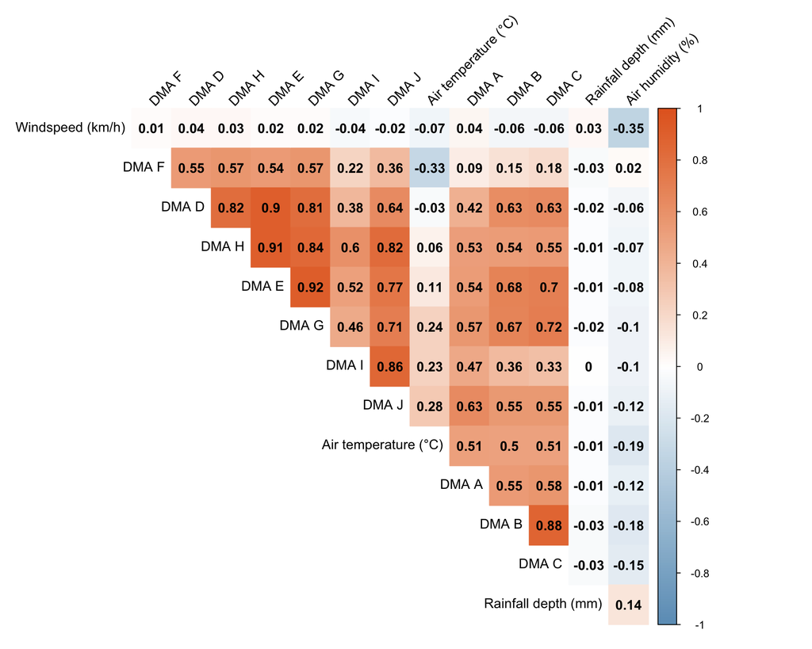

```r
numeric_df <- df_data %>%
  select(where(is.numeric))

# Calculate the correlation matrix for numeric columns
correlation_matrix <- cor(numeric_df, use = "complete.obs")

# Visualize the correlation matrix using corrplot
corrplot(correlation_matrix,
         method = "color",
         type = "upper",
         order = "hclust",
         tl.col = "black",
         tl.srt = 45,
         addCoef.col = "black",
         col = colorRampPalette(c("#6D9EC1", "white", "#E46726"))(200),
         diag = FALSE)
```